# Missing Data Case Study

```r
suppressPackageStartupMessages(library(tidyverse))
suppressPackageStartupMessages(library(broom))
suppressPackageStartupMessages(library(mice))
```

Consider predicting the air quality (ozone levels) in New York mid-year. We’ll use the `airquality` dataset, recorded for mid 1973:

```r
airquality
```

| Ozone | Solar.R | Wind | Temp | Month | Day |
| --- | --- | --- | --- | --- | --- |
| 41 | 190 | 7.4 | 67 | 5 | 1 |
| 36 | 118 | 8.0 | 72 | 5 | 2 |
| 12 | 149 | 12.6 | 74 | 5 | 3 |
| 18 | 313 | 11.5 | 62 | 5 | 4 |
| NA | NA | 14.3 | 56 | 5 | 5 |
| 28 | NA | 14.9 | 66 | 5 | 6 |
| 23 | 299 | 8.6 | 65 | 5 | 7 |
| 19 | 99 | 13.8 | 59 | 5 | 8 |
| 8 | 19 | 20.1 | 61 | 5 | 9 |
| NA | 194 | 8.6 | 69 | 5 | 10 |

[output cut: 143 more lines]

## Step 0: What data are missing?

There are some missing data. Use `md.pattern` to see patterns in missingness:

```
    Wind Temp Month Day Solar.R Ozone
111    1    1     1   1       1     1  0
35     1    1     1   1       1     0  1
5      1    1     1   1       0     1  1
2      1    1     1   1       0     0  2
       0    0     0   0       7    37 44
```

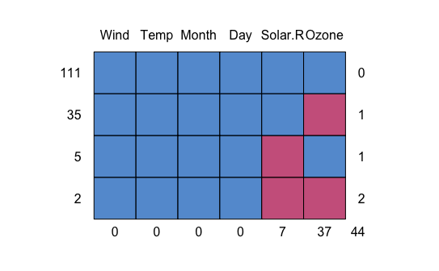

```r
md.pattern(airquality)
```

Fill in the following:

- There are **111** rows of complete data.
- There are **35** rows where only ozone is missing.
- There are **2** rows where both ozone and Solar.R are missing.
- There are **37** rows missing an ozone measurement.
- There are **44** `NA`’s in the dataset.

## Step 1: Handling Missing Data

### Any Ideas?

Here is a scatterplot of `Solar.R` and `Ozone`, with missing values “pushed” to the intercepts:

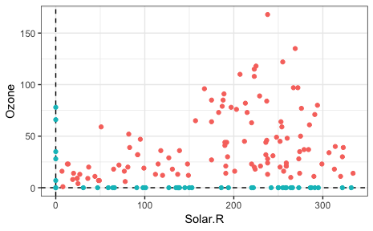

Discussion: What are some ways of handling the missing data? What are the consequences of these ways?

1. Remove data.
   - Remove rows with missing data (called the *complete case*).
     - Consequence: We’re throwing away information that could be used to reduce the final model function’s SE.
   - Remove rows where only the response is missing, and don’t use `Solar.R` in your regression (because it has some missing values).
     - Consequence: If `Solar.R` is predictive of `Ozone`, then we’d be losing that predictive power by not including it.
2. Impute:
   - Mean imputation: replace an `NA` with a prediction of its mean using other variables as predictors.
     - Consequence: imputed data would fall artificially close to the center of the “data cloud”. This means a fitted model function would have an artificially small SE.
   - Multiple imputation: impute with multiple draws from a predictive distribution.
     - A great choice! No real “consequences” here, aside from the inherent risk of biasing the model function that comes with imputing values.

### `mice`

First, remove the day and month columns (we won’t be using them):

```r
airquality <- airquality %>%
    select(-Month, -Day)
```

Make `m` random imputations using `mice::mice()`:

```r
(init <- mice(airquality, m = m, printFlag = FALSE))
```

```
Class: mids
Number of multiple imputations:  10
Imputation methods:
  Ozone Solar.R    Wind    Temp
  "pmm"   "pmm"      ""      ""
PredictorMatrix:
        Ozone Solar.R Wind Temp
Ozone       0       1    1    1
Solar.R     1       0    1    1
Wind        1       1    0    1
Temp        1       1    1    0
```

Check out the first imputed data set using `mice::complete()`. **WARNING**: there’s also a `tidyr::complete()`! Rows 5 and 6, for example, originally contained missing data.

| Ozone | Solar.R | Wind | Temp |
| --- | --- | --- | --- |
| 41 | 190 | 7.4 | 67 |
| 36 | 118 | 8.0 | 72 |
| 12 | 149 | 12.6 | 74 |
| 18 | 313 | 11.5 | 62 |
| 32 | 47 | 14.3 | 56 |
| 28 | 230 | 14.9 | 66 |
| 23 | 299 | 8.6 | 65 |
| 19 | 99 | 13.8 | 59 |
| 8 | 19 | 20.1 | 61 |
| 45 | 194 | 8.6 | 69 |

[output cut: 143 more lines]

Plot one of them:

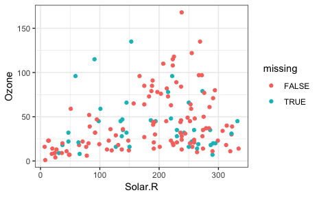

Now, fit a linear model on each data set using the `with()` generic function (method `with.mids()`:

```r
(fits <- with(init, lm(Ozone ~ Solar.R + Wind + Temp)))
```

Looks can be deceiving. This is not actually a list of length `m`! Unveil its true nature:

```r
unclass(fits) %>%
    str(max.level = 1)
```

```
List of 4
 $ call    : language with.mids(data = init, expr = lm(Ozone ~ Solar.R + Wind + Temp))
 $ call1   : language mice(data = airquality, m = m, printFlag = FALSE)
 $ nmis    : Named int [1:4] 37 7 0 0
  ..- attr(*, "names")= chr [1:4] "Ozone" "Solar.R" "Wind" "Temp"
 $ analyses:List of 10
```

It’s now easier to find the `lm` fit on the first dataset:

```r
fits$analyses[[1]]
```

```
Call:
lm(formula = Ozone ~ Solar.R + Wind + Temp)

Coefficients:
(Intercept)      Solar.R         Wind         Temp
  -37.86721      0.03151     -3.67677      1.41644
```

Or, we can obtain a summary of each fitted model:

| term | estimate | std.error | statistic | p.value |
| --- | --- | --- | --- | --- |
| (Intercept) | -37.86720628 | 20.33351990 | -1.862305 | 6.452946e-02 |
| Solar.R | 0.03150770 | 0.02123112 | 1.484034 | 1.399122e-01 |
| Wind | -3.67677300 | 0.58324707 | -6.303972 | 3.113483e-09 |
| Temp | 1.41644159 | 0.22697224 | 6.240594 | 4.296361e-09 |
| (Intercept) | -86.46855077 | 19.63111320 | -4.404669 | 2.012446e-05 |
| Solar.R | 0.07055887 | 0.02031650 | 3.472984 | 6.739813e-04 |
| Wind | -2.24565551 | 0.56381345 | -3.982976 | 1.060949e-04 |
| Temp | 1.76698485 | 0.21689782 | 8.146623 | 1.394613e-13 |
| (Intercept) | -75.67165737 | 19.01169337 | -3.980269 | 1.071922e-04 |
| Solar.R | 0.06895661 | 0.01991005 | 3.463407 | 6.965607e-04 |

[output cut: 30 more lines]

As an aside, let’s demonstrate that we can also use `mice` to fit GLM’s:

| term | estimate | std.error | statistic | p.value |
| --- | --- | --- | --- | --- |
| (Intercept) | 1.344120184 | 0.4725018510 | 2.8446877 | 5.071219e-03 |
| Solar.R | 0.001320813 | 0.0004933598 | 2.6771797 | 8.256919e-03 |
| Wind | -0.077466589 | 0.0135532520 | -5.7157197 | 5.765050e-08 |
| Temp | 0.035297141 | 0.0052742863 | 6.6923065 | 4.171614e-10 |
| (Intercept) | 0.227170511 | 0.4466233592 | 0.5086400 | 6.117569e-01 |
| Solar.R | 0.002273887 | 0.0004622164 | 4.9195285 | 2.269845e-06 |
| Wind | -0.047209613 | 0.0128272022 | -3.6804294 | 3.247990e-04 |
| Temp | 0.043348714 | 0.0049345971 | 8.7846510 | 3.464808e-15 |
| (Intercept) | 0.365800641 | 0.4622707429 | 0.7913126 | 4.300195e-01 |
| Solar.R | 0.001962542 | 0.0004841143 | 4.0538817 | 8.088602e-05 |

[output cut: 30 more lines]

## Step 3: Pool results

The last step is to pool the results together:

```r
pool(fits)
```

```
Class: mipo    m = 10
                estimate         ubar            b            t dfcom       df
(Intercept) -62.86896839 3.971573e+02 3.457833e+02 7.775189e+02   149 25.05962
Solar.R       0.06027971 4.235714e-04 3.490659e-04 8.075440e-04   149 26.25615
Wind         -3.06387961 3.273645e-01 4.299716e-01 8.003332e-01   149 18.04043
Temp          1.59681493 4.909472e-02 1.481133e-02 6.538719e-02   149 62.67163
                  riv    lambda       fmi
(Intercept) 0.9577102 0.4891992 0.5256074
Solar.R     0.9065118 0.4754819 0.5113388
Wind        1.4447770 0.5909647 0.6298456
Temp        0.3318577 0.2491691 0.2720353
```

The `estimate` column you see are just the averages of all `m` models.

Column names make more sense in light of the book “Multiple Imputation for Nonresponse in Surveys” by Rubin (1987), page 76-77:

- `estimate`: the average of the regression coefficients across `m` models.
- `ubar`: the average variance (i.e., average SE^2) across `m` models.
- `b`: the sample variance of the `m` regression coefficients.
- `t`: a final estimate of the SE^2 of each regression coefficient.
  - = `ubar + (1 + 1/m) b`
- `df`: the degrees of freedom associated with the final regression coefficient estimates.
  - An `alpha`-level CI: `estimate +/- qt(alpha/2, df) * sqrt(t)`.
- `riv`: the relative increase in variance due to randomness.
  - = `t/ubar - 1`